# 第四章 连续时间傅里叶变换

马越

北京理工大学机械与车辆学院  
Email: yuema@bit.edu.cn

## 目录

- **1. 非周期信号的表示：连续时间傅里叶变换**
- 2. 连续时间傅里叶变换的性质
- 3. 卷积性质
- 4. 乘积性质
- 5. 变换性质和变换对列表
- 6. 由线性常系数微分方程表征的系统

# 1. 非周期信号的表示：连续时间傅里叶变换

## 动机示例：周期方波

在一个周期中,

$$x_{T}(t)= \begin{cases}1, & |t|<T_{1} \\ 0, & T_{1}<|t|<T / 2\end{cases}$$

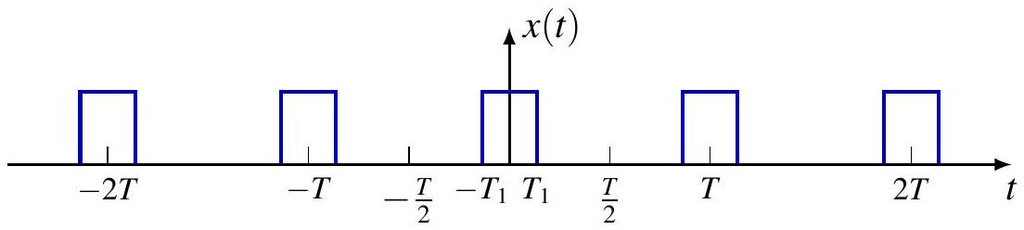

在 $\omega_k = k\omega_0$ 处的频率分量满足：

$$T\hat{x}_T[k] = \frac{2 \sin (k\omega_0 T_1)}{k\omega_0} = \left. \frac{2 \sin (\omega T_1)}{\omega} \right|_{\omega=k\omega_0}$$

$T\hat{x}_T[k]$ 是在 $\omega_k = k\omega_0$ 处采样的包络线 $X(j\omega) \triangleq \frac{2 \sin(\omega T_1)}{\omega}$ 的值。

## 动机示例：周期方波

当 $T_1$ 固定且周期 $T$ 不同时的 $X(j\omega_k)$：

- 离散频率间隔为 $\omega_k = k\frac{2\pi}{T}$
- 图中展示了三种情况：
  - $T = 4T_1$
  - $T = 8T_1$
  - $T = 16T_1$
- 第一个零点位于 $\frac{\pi}{T_1}$

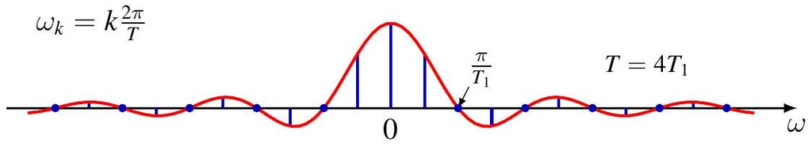

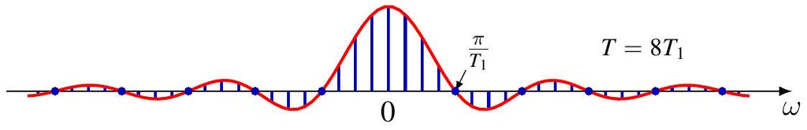

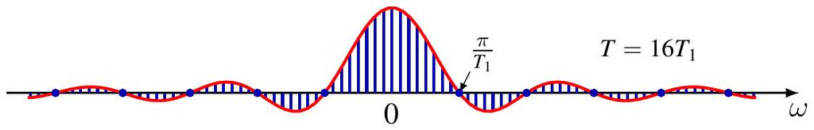

**结论：** 随着 $T \to \infty$，离散频率的采样变得越来越密集。

## 动机示例：周期方波

当 $T \to \infty$ 时，$x_T(t) \to x(t) \triangleq u(t + T_1) - u(t - T_1)$，即矩形脉冲 。

$$\begin{aligned}
x_T(t) &= \sum_{k=-\infty}^{\infty} \hat{x}_T[k] e^{j\omega_k t} = \sum_{k=-\infty}^{\infty} \frac{1}{T} X(j\omega_k) e^{j\omega_k t} & (T\hat{x}[k] = X(j\omega_k)) \\
&= \sum_{k=-\infty}^{\infty} \frac{\omega_0}{2\pi} X(j\omega_k) e^{j\omega_k t} & (\omega_0 = \frac{2\pi}{T}) \\
&= \frac{1}{2\pi} \sum_{k=-\infty}^{\infty} X(j\omega_k) e^{j\omega_k t} \Delta\omega & (\Delta\omega = \omega_0) \\
&\to \frac{1}{2\pi} \int_{-\infty}^{\infty} X(j\omega) e^{j\omega t} d\omega & (\Delta\omega = \omega_0 \to 0)
\end{aligned}$$

因此：

$$x(t) = \frac{1}{2\pi} \int_{-\infty}^{\infty} X(j\omega) e^{j\omega t} d\omega$$

## 动机示例：周期方波

对于$X(j\omega)$ ，

$$\begin{aligned}
X(j\omega_k) &= T\hat{x}_T[k] \\
&= \int_{-T/2}^{T/2} x_T(t)e^{-j\omega_k t} dt \\
&= \int_{-T/2}^{T/2} x(t)e^{-j\omega_k t} dt \quad (在 |t| \le T/2 时，x_T(t) = x(t)) \\
&= \int_{-\infty}^{\infty} x(t)e^{-j\omega_k t} dt \quad (在 |t| > T/2 时，x(t) = 0)
\end{aligned}$$

所以，

$$X(j\omega) = \int_{-\infty}^{\infty} x(t)e^{-j\omega t} dt$$

## 动机示例：周期方波

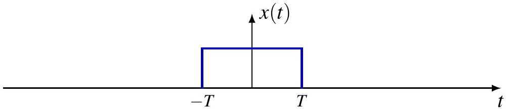

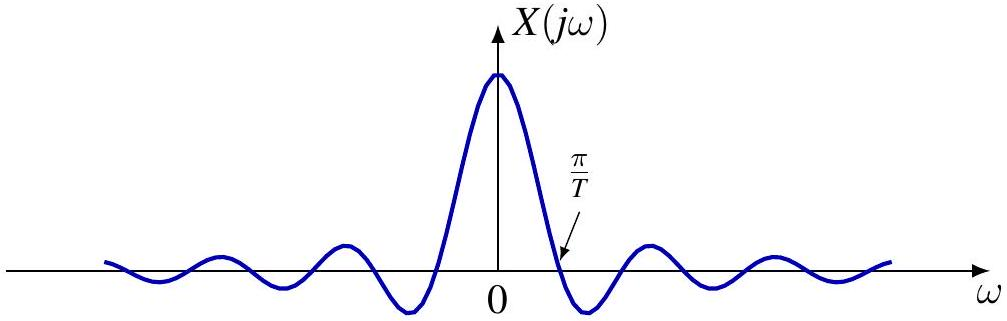

## 非周期信号的连续时间傅里叶变换 (CTFT)

对于一个支撑集为 $\text{supp } x \subset [-T_1, T_1]$ 的非周期信号 $x$，定义周期为 $T > 2T_1$ 的周期延拓信号：

$$x_T(t) = \sum_{k=-\infty}^{\infty} x(t - kT)$$

那么

$$x(t) = x_T(t), \quad |t| < \frac{T}{2}$$

当 $T \to \infty$ 时，

$$x_T(t) \to x(t), \quad \forall t \in \mathbb{R}$$

$x_T$ 具有傅里叶级数表示：

$$x_T(t) = \sum_{k=-\infty}^{\infty} \hat{x}_T[k]e^{jk\omega_0 t}, \quad \omega_0 = \frac{2\pi}{T}$$

## 非周期信号的连续时间傅里叶变换

定义：

$$X(j\omega) = \int_{-\infty}^{\infty} x(t)e^{-j\omega t} dt$$

$X(j\omega)$ 是 $T\hat{x}_T[k]$ 的包络线，

$$\begin{aligned}
\hat{x}_T[k] &= \frac{1}{T} \int_{-\frac{T}{2}}^{\frac{T}{2}} x_T(t)e^{-jk\omega_0 t} dt = \frac{1}{T} \int_{-\frac{T}{2}}^{\frac{T}{2}} x(t)e^{-jk\omega_0 t} dt \\
&= \frac{1}{T} \int_{-\infty}^{\infty} x(t)e^{-jk\omega_0 t} dt = \frac{1}{T} X(jk\omega_0) = \frac{\omega_0}{2\pi} X(jk\omega_0)
\end{aligned}$$

所以：

$$\begin{aligned}
x(t) &= \lim_{T \to \infty} x_T(t) = \lim_{T \to \infty} \sum_{k=-\infty}^{\infty} \frac{\omega_0}{2\pi} X(jk\omega_0)e^{jk\omega_0 t} \\
&= \frac{1}{2\pi} \int_{-\infty}^{\infty} X(j\omega)e^{j\omega t} d\omega
\end{aligned}$$

## 连续时间傅里叶变换对

**傅里叶变换（分析方程）** ：
$$X(j\omega) = \mathcal{F}(x)(j\omega) = \int_{-\infty}^{\infty} x(t) e^{-j\omega t} dt$$
* $X(j\omega)$ 被称为 $x(t)$ 的**频谱** 。

**逆傅里叶变换（综合方程）** ：
$$x(t) = \mathcal{F}^{-1}(X)(t) = \frac{1}{2\pi} \int_{-\infty}^{\infty} X(j\omega) e^{j\omega t} d\omega$$
* 这是在**连续频率**上的复指数信号的叠加；

- 频率 $\omega$ 具有“幅度” $X(j\omega) \frac{d\omega}{2\pi}$ 。

## 等价表示与应用

同一信号的两种等价表示：

- 时域 vs. 频域：$x(t) \stackrel{\mathcal{F}}{\longleftrightarrow} X(j \omega)$

**其他领域的应用**：

- **概率论**：具有密度函数 $p(x)$ 的随机变量 $X$ 的特征函数
  $$\varphi_{X}(t)=\mathbb{E}\left[e^{j t X}\right]=\int_{-\infty}^{\infty} p(x) e^{j x t} d x$$
- **量子力学**：
  - 位置表示：波函数 $\psi(x)$（$|\psi(x)|^{2}$ 是在位置 $x$ 发现粒子的概率密度）
  - 动量表示：$\Psi(p)$
    $$\Psi(p)=\frac{1}{\sqrt{2 \pi \hbar}} \int_{-\infty}^{\infty} \psi(x) e^{-j p x / \hbar} d x$$
  - $|\Psi(p)|^{2}$ 是发现具有动量 $p$ 的粒子的概率密度

## $L_{1}$ 信号的定义

回顾微积分，对于实值函数 $x$，广义积分定义为：

$$\int_{\mathbb{R}} x(t) d t \triangleq \lim _{T_{1}, T_{2} \rightarrow \infty} \int_{-T_{1}}^{T_{2}} x(t) d t$$

如果 $x \in L_{1}(\mathbb{R})$，即 $\|x\|_{1}=\int_{\mathbb{R}}|x(t)| d t<\infty$，则该积分是**定义良好 (well-defined)** 的。 对于复值函数 $x=u+j v$ 同样适用，因为 $|u|,|v| \leq|x|$。

对于信号 $x \in L_{1}(\mathbb{R})$：

- $x(t) e^{-j \omega t} \in L_{1}(\mathbb{R})$，因为 $\left|x(t) e^{-j \omega t}\right|=|x(t)|$。
- 对于每个 $\omega$，傅里叶变换 $X(j \omega)$ 都是定义良好的广义积分。

## 例子：右边衰减指数信号

$$x(t)=e^{-a t} u(t), \quad a>0$$

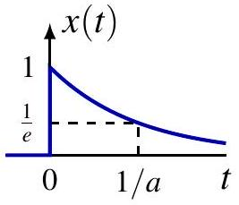

$$\begin{aligned}
X(j \omega) & =\int_{0}^{\infty} e^{-(a+j \omega) t} d t \\
& =-\left.\frac{1}{a+j \omega} e^{-(a+j \omega) t}\right|_{0} ^{\infty}=\frac{1}{a+j \omega}
\end{aligned}$$

*(注：该公式也适用于实部 $\operatorname{Re} a>0$ 的复数 $a$)*

对于 $a>0$：
$$|X(j \omega)|=\frac{1}{\sqrt{a^{2}+\omega^{2}}}, \quad \arg X(j \omega)=-\arctan \frac{\omega}{a}$$

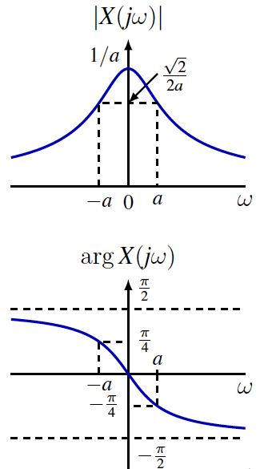

## 例子：双边衰减指数信号

$$x(t)=e^{-a|t|}, \quad a>0$$

$$\begin{aligned}
X(j \omega) & =\int_{-\infty}^{\infty} e^{-a|t|} e^{-j \omega t} d t \\
& =\int_{-\infty}^{0} e^{(a-j \omega) t} d t+\int_{0}^{\infty} e^{-(a+j \omega) t} d t \\
& =\frac{1}{a-j \omega}+\frac{1}{a+j \omega}=\frac{2 a}{a^{2}+\omega^{2}}
\end{aligned}$$

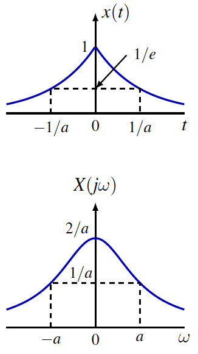

## 例子：高斯信号 (Gaussian)

对于 $a>0$，

$$x(t)=e^{-a t^{2}} \stackrel{\mathcal{F}}{\longleftrightarrow} X(j \omega)=\sqrt{\frac{\pi}{a}} e^{-\frac{\omega^{2}}{4 a}}$$

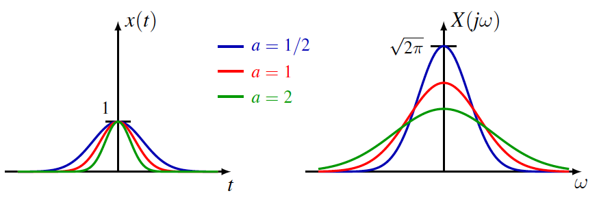

特别地，如果 $a=1/2$：
$$x(t)=e^{-\frac{1}{2} t^{2}} \stackrel{\mathcal{F}}{\longleftrightarrow} X(j \omega)=\sqrt{2 \pi} e^{-\frac{1}{2} \omega^{2}}$$
即高斯函数是傅里叶变换的特征函数。

## 高斯信号变换证明

利用微分方程和分部积分证明：

$$\begin{aligned}
\frac{d}{d \omega} X(j \omega) & =\int_{-\infty}^{\infty} e^{-a t^{2}}(-j t) e^{-j \omega t} d t=\frac{j}{2 a} \int_{-\infty}^{\infty}\left(\frac{d}{d t} e^{-a t^{2}}\right) e^{-j \omega t} d t \\
&=-\frac{j}{2 a} \int_{-\infty}^{\infty} e^{-a t^{2}}\left(\frac{d}{d t} e^{-j \omega t}\right) d t \quad \text { (分部积分) } \\
&=-\frac{\omega}{2 a} X(j \omega)
\end{aligned}$$

解微分方程 $\frac{d}{d \omega} X(j \omega)=-\frac{\omega}{2 a} X(j \omega)$ 并利用 $X(0)=\sqrt{\pi/a}$ 可得结果。

## $L_{1}$ 信号的傅里叶逆变换

给定 $X(j\omega)$，逆变换是否等于 $x(t)$？

$$x(t) \stackrel{?}{=} \mathcal{F}^{-1}\{X\}(t)=\frac{1}{2 \pi} \int_{-\infty}^{\infty} X(j \omega) e^{j \omega t} d \omega$$

**定理**：如果 $x \in L_{1}(\mathbb{R})$ 是连续的，且 $X=\mathcal{F}\{x\} \in L_{1}(\mathbb{R})$，那么 $x=\mathcal{F}^{-1}\{X\}$。 - 例如：双边衰减指数，高斯信号。

**注意**：对于 $x \in L_1$，其变换 $X$ 不一定属于 $L_1$。 - 例如：单边衰减指数，矩形脉冲。

**主值积分**：通常将逆变换解释为柯西主值 (Principal Value)：
$$\lim _{W \rightarrow \infty} \frac{1}{2 \pi} \int_{-W}^{W} X(j \omega) e^{j \omega t} d \omega$$

**狄利克雷定理**：如果 $x \in L_1$ 且满足狄利克雷条件，逆变换收敛于 $\frac{x\left(t_{+}\right)+x\left(t_{-}\right)}{2}$（吉布斯现象）。

## 例子：矩形脉冲 (Rectangular Pulse)

$$x(t)=u(t+T)-u(t-T)$$

$$X(j \omega)=\int_{-T}^{T} e^{-j \omega t} d t=\frac{2 \sin (\omega T)}{\omega}$$

当 $T \rightarrow \infty$ 时：

- 频域：$\frac{\sin (\omega T)}{\pi \omega} \rightarrow \delta(\omega)$
- 时域：$x(t) \rightarrow 1$ (直流信号)

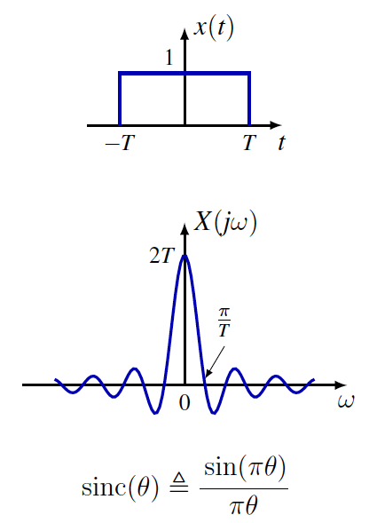

## 例子：理想低通滤波器

频率响应：
$$H(j \omega)=u\left(\omega+\omega_{c}\right)-u\left(\omega-\omega_{c}\right)$$

冲激响应（逆变换）：
$$h(t)=\frac{1}{2 \pi} \int_{-\omega_{c}}^{\omega_{c}} e^{j \omega t} d \omega=\frac{\sin \left(\omega_{c} t\right)}{\pi t}$$

注意：$h(t) \notin L_{1}(\mathbb{R})$ 但 $H(j \omega) \in L_{1}(\mathbb{R})$。

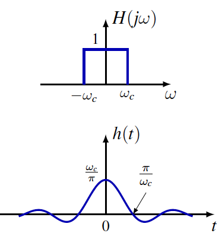

当 $\omega_{c} \rightarrow \infty$ 时，

- 时域：$h(t) \rightarrow \delta(t)$
- 频域：$H(j \omega) \rightarrow 1$（通过所有频率）

## 对偶性 (Duality)

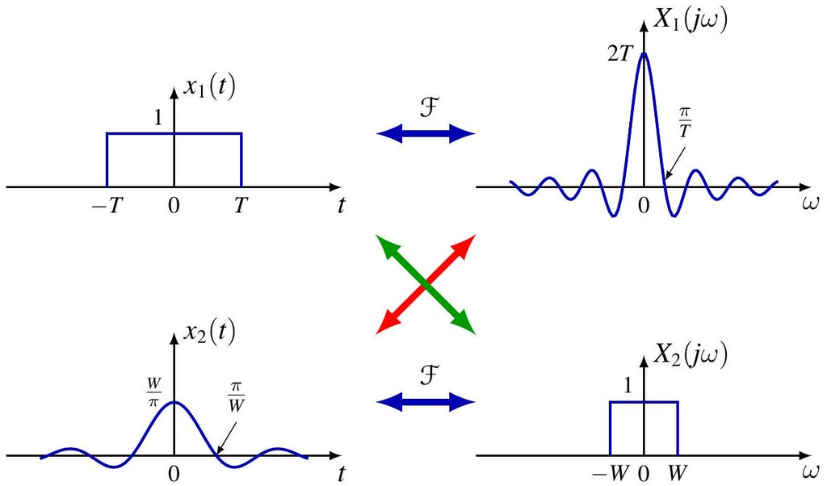

- 时间脉冲 $\leftrightarrow$ 频域 Sinc
- 时间 Sinc $\leftrightarrow$ 频域脉冲 (低通滤波器)

## 广义傅里叶变换定义

如果 $x_n \rightarrow x$，定义 $x$ 的傅里叶变换为：
$$X(j \omega)=\mathcal{F}\{x\} \triangleq \lim _{n} \mathcal{F}\left\{x_{n}\right\}$$

更正式地，基于**分布/广义函数**理论，对于测试函数 $\phi$：
$$\frac{1}{2 \pi} \int_{\mathbb{R}} X(j \omega) \phi(\omega) d \omega=\int_{\mathbb{R}} x(t) \Phi(j t) d t$$

**施瓦兹空间 (Schwarz Space) $\mathcal{S}$**：

- 无穷可微且**速降 (rapidly decreasing)** 的函数空间。
- 例如：高斯函数 $g(t)=e^{-a t^{2}} \in \mathcal{S}$。
- 性质：$\phi \in \mathcal{S} \Longrightarrow \Phi \in \mathcal{S}$。

## 例子：单位冲激 $\delta$

**方法 1**：作为理想低通滤波器的极限。
$$h_{W}(t)=\frac{\sin (W t)}{\pi t} \stackrel{\mathcal{F}}{\longleftrightarrow} H_{W}(j \omega)=u(\omega+W)-u(\omega-W)$$
当 $W \rightarrow \infty$，$h_W \to \delta$，且 $H_W \to 1$。
$$\therefore \mathcal{F}\{\delta\}=1$$

**方法 2**：使用广义定义。
$$\frac{1}{2 \pi} \int_{\mathbb{R}} X(j \omega) \phi(\omega) d \omega=\int_{\mathbb{R}} \delta(t) \Phi(j t) d t=\Phi(0)=\int_{\mathbb{R}} 1 \cdot \phi(\omega) d \omega$$
因此 $X(j\omega)=1$。 $\delta$ 具有**白色频谱 (white spectrum)**，包含等量的所有频率。

## 例子：直流信号 1

**方法 1**：作为矩形脉冲的极限。
$$x_{T}(t) \longleftrightarrow X_{T}(j \omega)=\frac{2 \sin (\omega T)}{\omega}$$
当 $T \rightarrow \infty$，$x_T \to 1$，且 $X_T \to 2\pi\delta(\omega)$。
$$\therefore \mathcal{F}\{1\}=2 \pi \delta(\omega)$$

**方法 2**：使用广义定义。
$$\frac{1}{2 \pi} \int_{\mathbb{R}} X(j \omega) \phi(\omega) d \omega=\int_{\mathbb{R}} 1 \cdot \Phi(j t) d t=2 \pi \phi(0)=\int_{\mathbb{R}} 2 \pi \delta(\omega) \phi(\omega) d \omega$$
也就是：
$$2\pi\delta(\omega) = \int_{-\infty}^{\infty} e^{-j\omega t} dt$$
**直流信号的频谱是零频率处的冲激！**

## 例子：复指数信号

令 $x(t)=e^{j \omega_{0} t}$。 根据
$$2\pi\delta(\omega) = \int_{-\infty}^{\infty} e^{-j\omega t} dt$$
可以得到：
$$2\pi\delta(\omega - \omega_0) = \int_{\mathbb{R}} e^{j(\omega_0 - \omega)t} dt$$

因此：
$$\mathcal{F}\{e^{j \omega_{0} t}\} = 2 \pi \delta\left(\omega-\omega_{0}\right)$$

$e^{j \omega_{0} t}$ 的频谱是 $\omega_{0}$ 处的冲激。

## 例子：复指数信号

连续时间傅里叶变换（CT Fourier transform）可以被看作是向连续“基”函数空间的**“正交”展开**：

$$X(j\omega) = \langle x, e^{j\omega t} \rangle = \int_{\mathbb{R}} x(t) \overline{e^{j\omega t}} dt$$
$$2\pi\delta(\omega_1 - \omega_2) = \int_{\mathbb{R}} e^{j(\omega_1 - \omega_2)t} dt = \int_{\mathbb{R}} e^{j\omega_1 t} \overline{e^{j\omega_2 t}} dt$$
* $e^{j\omega_1 t}$ 与 $e^{j\omega_2 t}$ 是正交的，如果 $\omega_1 \neq \omega_2$。

以及

$$x(t) = \frac{1}{2\pi} \int_{\mathbb{R}} \langle x, e^{j\omega t} \rangle e^{j\omega t} d\omega$$

## 周期信号的傅里叶变换

### 周期信号的频谱

基频为 $\omega_0$ 的周期信号具有傅里叶级数：
$$x(t)=\sum_{k=-\infty}^{\infty} \hat{x}[k] e^{j k \omega_{0} t}$$

利用线性和复指数的变换：
$$\begin{aligned}
X(j \omega) & =\mathcal{F}\left\{\sum_{k=-\infty}^{\infty} \hat{x}[k] e^{j k \omega_{0} t}\right\} \\
& =\sum_{k=-\infty}^{\infty} \hat{x}[k] \mathcal{F}\left\{e^{j k \omega_{0} t}\right\} \\
& =\sum_{k=-\infty}^{\infty} 2 \pi \hat{x}[k] \delta\left(\omega-k \omega_{0}\right)
\end{aligned}$$

**结论**：周期信号的频谱由**谐波相关频率处的冲激**组成！冲激的面积是 $2\pi$ 乘以傅里叶级数系数。

## 例子：正弦和余弦

**余弦**：$x(t) = \cos(\omega_0 t) = \frac{1}{2} e^{j \omega_{0} t}+\frac{1}{2} e^{-j \omega_{0} t}$
$$X(j \omega) = \pi \delta\left(\omega-\omega_{0}\right)+\pi \delta\left(\omega+\omega_{0}\right)$$

**正弦**：$x(t) = \sin(\omega_0 t) = \frac{1}{2j} e^{j \omega_{0} t}-\frac{1}{2j} e^{-j \omega_{0} t}$
$$X(j \omega) = \frac{\pi}{j} \delta\left(\omega-\omega_{0}\right)-\frac{\pi}{j} \delta\left(\omega+\omega_{0}\right)$$

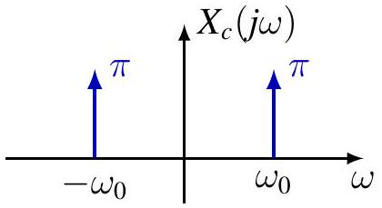

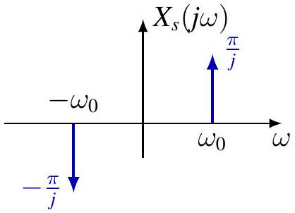

## 例子：周期方波

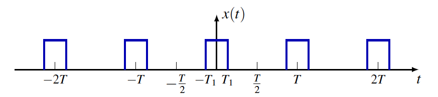

$$\hat{x}[k]=\frac{Sin(k\omega t)}{k \pi}$$

$$X(j \omega)=\sum_{k=-\infty}^{\infty}\frac{2 Sin(k\omega t)}{k } \delta(\omega-k\omega_0)$$

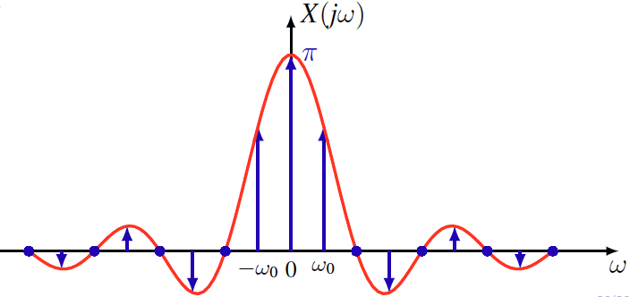

## 例子：周期冲激串

$$x(t)=\sum_{k=-\infty}^{\infty} \delta(t-k T)$$

傅里叶系数 $\hat{x}[k] = 1/T$。 傅里叶变换：

$$X(j \omega)=\sum_{k=-\infty}^{\infty} \frac{2 \pi}{T} \delta\left(\omega-k \frac{2 \pi}{T}\right)$$

时域中的冲激串 $\longleftrightarrow$ 频域中的冲激串。

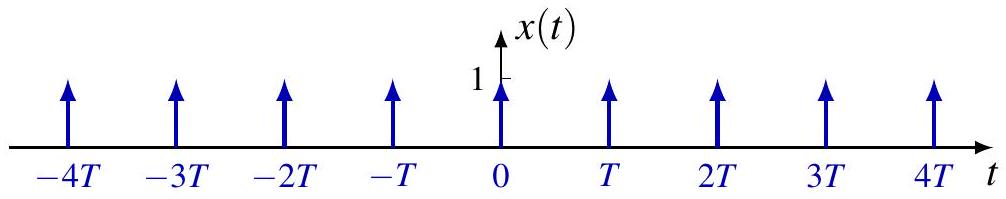

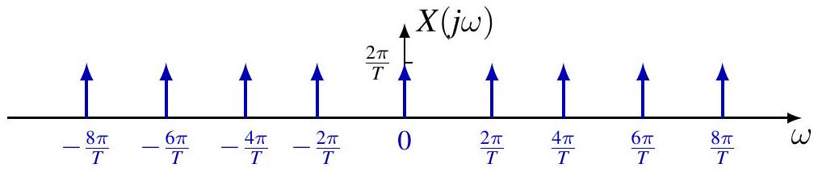

## 目录

- 1. 非周期信号的表示：连续时间傅里叶变换
- **2. 连续时间傅里叶变换的性质**
- 3. 卷积性质
- 4. 乘积性质
- 5. 变换性质和变换对列表
- 6. 由线性常系数微分方程表征的系统

# 2. 连续时间傅里叶变换的性质

## 回顾：$L_1(\mathbb{R})$ 函数的傅里叶变换

作为主值（Principal values）的傅里叶变换及其逆变换：

$$\mathcal{F}\{x\}(j\omega) = \lim_{T \to \infty} \int_{-T}^{T} x(t)e^{-j\omega t} dt$$

$$\mathcal{F}^{-1}(X)(t) = \lim_{W \to \infty} \frac{1}{2 \pi} \int_{-W}^{W} X(j\omega)e^{j\omega t} d\omega$$

### 定理（点向逆变换 Pointwise inversion）

1. 如果 $x \in L_1(\mathbb{R})$ 在所有有限区间上均满足狄里赫利（Dirichlet）条件，则：
   $$(\mathcal{F}^{-1} \circ \mathcal{F}\{x\})(t) = \frac{x(t_+) + x(t_-)}{2}, \quad \forall t$$
2. 如果 $X \in L_1(\mathbb{R})$ 在所有有限区间上均满足狄里赫利（Dirichlet）条件，则：
   $$(\mathcal{F} \circ \mathcal{F}^{-1}\{X\})(j\omega) = \frac{X(j\omega_+) + X(j\omega_-)}{2}, \quad \forall \omega$$
3. 如果 $x \in C(\mathbb{R}) \cap L_1(\mathbb{R})$ 且 $\mathcal{F}\{x\} \in L_1(\mathbb{R})$，那么：
   $$\mathcal{F}^{-1} \circ \mathcal{F}\{x\} = x$$

## 回顾: $L_1(\mathbb{R})$ 函数的傅里叶变换

傅里叶变换对

| case | $x(t)$ | $X(j \omega)$ |
| --- | --- | --- |
| 1 | $e^{-a t} u(t), \quad \operatorname{Re} a>0$ | $\frac{1}{a+j \omega}$ |
| 3 | $e^{-a\\|t\\|}, \quad \operatorname{Re} a>0$ | $\frac{2 a}{a^{2}+\omega^{2}}$ |
| 3 | $e^{-a t^{2}}, \quad a>0$ | $\sqrt{\frac{\pi}{a}} e^{-\frac{\omega^{2}}{4 a}}$ |
| 1 | $u(t+T)-u(t-T)$ | $\frac{2 \sin (\omega T)}{\omega}$ |
| 2 | $\frac{\sin \left(\omega_{c} t\right)}{\pi t}$ | $u\left(\omega+\omega_{c}\right)-u\left(\omega-\omega_{c}\right)$ |

## 回顾: 广义函数的傅里叶变换

**施瓦茨空间 (Schwartz space)** $\mathcal{S} = \mathcal{S}(\mathbb{R})$，即快速递减函数空间：

$$\mathcal{S} = \{ \phi \in C^\infty(\mathbb{R}) : \|\phi\|_{\ell,k} < \infty, \forall \ell, k \in \mathbb{N} \}$$

其中 $\|\phi\|_{\ell,k} = \sup_{t \in \mathbb{R}} |t^\ell \phi^{(k)}(t)|$。注意 $\mathcal{F}\{\mathcal{S}\} = \mathcal{S}$。

**缓增广义函数 (Tempered distributions)** 的傅里叶变换定义如下：

$$(x, \phi) \triangleq \int_{\mathbb{R}} x(\xi)\phi(\xi)d\xi$$

- 如果在广义函数意义下 $x_n \to x$，那么其傅里叶变换定义为：$\mathcal{F}\{x\} \triangleq \lim_{n} \mathcal{F}\{x_n\}$（广义函数意义下）。

$$(x, \phi) = \lim_{n} (x_n, \phi) \Longrightarrow (\mathcal{F}\{x\}, \phi) \triangleq \lim_{n} (\mathcal{F}\{x_n\}, \phi), \quad \forall \phi \in \mathcal{S}$$

- 或者，另一种等价定义为：
  $$(\mathcal{F}\{x\}, \phi) \triangleq (x, \mathcal{F}\{\phi\}), \quad \forall \phi \in \mathcal{S}$$

## 回顾: 广义函数的傅里叶变换

傅里叶变换对

| $x(t)$ | $X(j \omega)$ |
| --- | --- |
| $\delta(t)$ | 1 |
| $\delta\left(t-t_{0}\right)$ | $e^{-j \omega t_{0}}$ |
| 1 | $2 \pi \delta(\omega)$ |
| $e^{j \omega_{0} t}$ | $2 \pi \delta\left(\omega-\omega_{0}\right)$ |

$$\begin{gathered}
\int_{\mathbb{R}} \delta\left(t-t_{0}\right) e^{-j \omega t} d t=e^{-j \omega t_{0}}, \quad \int_{\mathbb{R}} e^{j\left(\omega_{1}-\omega_{2}\right) t} d t=2 \pi \delta\left(\omega_{1}-\omega_{2}\right) \\
\int_{\mathbb{R}} X(j \omega) e^{j \omega t} d \omega=\int_{\mathbb{R}} \int_{\mathbb{R}} x(\tau) e^{j \omega(t-\tau)} d \tau d \omega=\int_{\mathbb{R}} x(\tau) 2 \pi \delta(t-\tau) d \tau=2 \pi x(t)
\end{gathered}$$

## 回顾: Fourier Transform for Periodic Functions

### 傅里叶级数 (Fourier series)

$$x(t) = \sum_{k=-\infty}^{\infty} \hat{x}[k]e^{jk\omega_0 t}$$

### 傅里叶变换 (Fourier transform)

$$X(j\omega) = \sum_{k=-\infty}^{\infty} 2\pi\hat{x}[k]\delta(\omega - k\omega_0)$$

### 等价表示 (Equivalent representation)

- $\hat{x}[k]$ 是在 $\omega_k = k\omega_0$ 处分量的**幅度**。
- $\hat{x}[k]\delta(\omega - k\omega_0)$ 是在 $\omega_k = k\omega_0$ 处分量的**密度**。

### 类比：概率论中的离散随机变量 $x$ (Cf. discrete random variable $x$ in probability)

$$\mathbb{E}f(X) = \sum_{n} f(x_n)p_n = \int_{\mathbb{R}} f(x)p(x)dx$$

其中概率密度函数定义为：
$$p(x) = \sum_{n} p_n\delta(x - x_n)$$

## 回顾: 傅里叶级数与傅里叶变换的关系

$$x_T(t) = \sum_{k=-\infty}^{\infty} x(t - kT)$$

**注意：** 换句话说，$x$ 是周期信号 $x_T$ 的一个周期。

## 连续时间傅里叶变换的性质

线性

$$\mathcal{F}\{a x+b y\}=a \mathcal{F}\{x\}+b \mathcal{F}\{y\}$$

时移

$$\mathcal{F}\left\{\tau_{t_{0}} x\right\}=E_{-t_{0}} \mathcal{F}\{x\} \quad \text { or } \quad x\left(t-t_{0}\right) \stackrel{\mathcal{F}}{\longleftrightarrow} e^{-j \omega t_{0}} X(j \omega)$$

其中 $\left(E_{a} f\right)(s)=e^{j a s} f(s)$ 证明。

$$\int_{\mathbb{R}} x\left(t-t_{0}\right) e^{-j \omega t} d t=\int_{\mathbb{R}} x(s) e^{-j \omega\left(s+t_{0}\right)} d s=e^{-j \omega t_{0}} \int_{\mathbb{R}} x(s) e^{-j \omega s} d s$$

频移

$$\mathcal{F}\left\{E_{\omega_{0}} x\right\}=\tau_{\omega_{0}} \hat{x} \quad \text { or } \quad e^{j \omega_{0} t} x(t) \stackrel{\mathcal{F}}{\longleftrightarrow} X\left(j\left(\omega-\omega_{0}\right)\right)$$

## 例: 多径效应

**发送端 (Transmitter)**：$x(t)$

**接收端 (Receiver)**：$y(t) = a_0x(t) + a_1x(t - \tau)$

$$\begin{aligned}
Y(j \omega) & =a_{0} X(j \omega)+a_{1} e^{-j \omega \tau} X(j \omega) \\
& =\left(a_{0}+a_{1} e^{-j \omega \tau}\right) X(j \omega)
\end{aligned}$$

令 $x(t)=u(t+T)-u(t-T)$.

$$X(j \omega)=\frac{2 \sin (\omega T)}{\omega}$$

$$Y(j \omega)=\left(a_{0}+a_{1} e^{-j \omega \tau}\right) \frac{2 \sin (\omega T)}{\omega}$$

对于 $a_{0}=a_{1}=1$,

$$Y(j \omega)=4 e^{-j \omega \tau / 2} \cos \left(\frac{\omega \tau}{2}\right) \frac{\sin (\omega T)}{\omega}$$

[figure not shown]

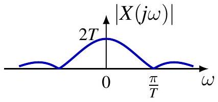

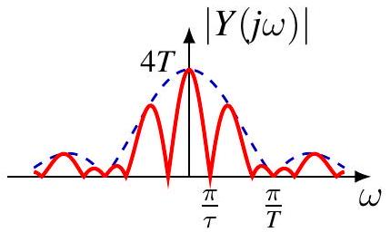

## 例: 调制

**基带信号 (Baseband signal)**：$x(t)$

**已调信号 (Modulated signal)**：通常表示为 $y(t)$ 或 $s(t)$
$$\begin{aligned}
& y(t)=x(t) \cos \left(\omega_{c} t\right)=\frac{1}{2} x(t)\left(e^{j \omega_{c} t}+e^{-j \omega_{c} t}\right) \\
& Y(j \omega)=\frac{1}{2} X\left(j\left(\omega-\omega_{c}\right)\right)+\frac{1}{2} X\left(j\left(\omega+\omega_{c}\right)\right)
\end{aligned}$$

对于 $x(t)=u(t+T)-u(t-T)$,

$$Y(j \omega)=\frac{\sin \left(\left(\omega-\omega_{c}\right) T\right)}{\omega-\omega_{c}}+\frac{\sin \left(\left(\omega+\omega_{c}\right) T\right)}{\omega+\omega_{c}}$$

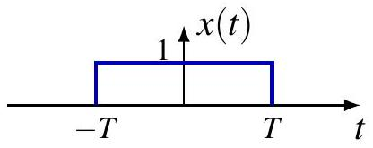

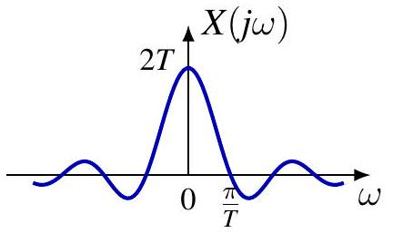

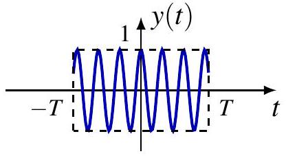

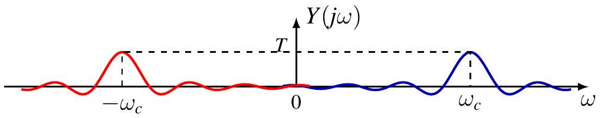

## 连续时间傅里叶变换的性质

时间反转

$$\mathcal{F}\{R x\}=R \mathcal{F}\{x\} \quad \text { or } \quad x(-t) \stackrel{\mathcal{F}}{\longleftrightarrow} X(-j \omega)$$

共轭

$$\mathcal{F}\left\{x^{*}\right\}=R \overline{\mathcal{F}\{x\}} \quad \text { or } \quad x^{*}(t) \stackrel{\mathcal{F}}{\longleftrightarrow} X^{*}(-j \omega)$$

**证明**：  
$\mathcal{F} \{x^*\}(j\omega) = \int_{\mathbb{R}} x^*(t)e^{-j\omega t} dt = \left( \int_{\mathbb{R}} x(t)e^{j\omega t} dt \right)^* = X^*(-j\omega)$ **对称性**

- $x$ 为偶函数 $\iff X$ 为偶函数； $x$ 为奇函数 $\iff X$ 为奇函数
- $x$ 为实信号 $\iff X(-j\omega) = X^*(j\omega)$（共轭对称性）
- $x$ 为实且偶 $\iff X$ 为实且偶
- $x$ 为实且奇 $\iff X$ 为纯虚且奇

## 例

对于 $a>0$,

$$x(t)= \begin{cases}e^{-a t}, & t>0 \\ -e^{a t}, & t<0\end{cases}$$

令 $y(t)=e^{-a t} u(t)$, 而且

$$Y(j \omega)=\frac{1}{a+j \omega}$$

由于 $x(t)=y(t)-y(-t)$.

$$\begin{aligned}
X(j \omega) & =Y(j \omega)-Y(-j \omega) \\
& =\frac{1}{a+j \omega}-\frac{1}{a-j \omega}=\frac{-2 j \omega}{a^{2}+\omega^{2}}
\end{aligned}$$

$x$ 为实且奇 $\iff X$ 为纯虚且奇

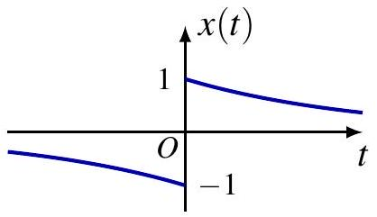

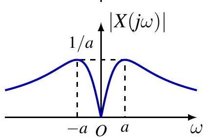

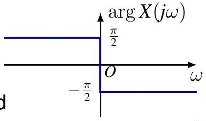

## 时间与频率尺度变换

对于 $a \neq 0$,

$$\mathcal{F}\left\{S_{a} x\right\}=\frac{1}{|a|} S_{\frac{1}{a}} \mathcal{F}\{x\} \quad \text { or } \quad x(a t) \stackrel{\mathcal{F}}{\longleftrightarrow} \frac{1}{|a|} X\left(\frac{j \omega}{a}\right)$$

**证明**。通过变量替换 $\tau = at$。

对于 $a > 0$：

$$\int_{-\infty}^{\infty} x(at)e^{-j\omega t} dt = \int_{-\infty}^{\infty} x(\tau)e^{-j\frac{\omega}{a}\tau} \frac{d\tau}{a} = \frac{1}{a} X\left( \frac{j\omega}{a} \right)$$

对于 $a < 0$：

$$\int_{-\infty}^{\infty} x(at)e^{-j\omega t} dt = \int_{\infty}^{-\infty} x(\tau)e^{-j\frac{\omega}{a}\tau} \frac{d\tau}{a} = -\frac{1}{a} X\left( \frac{j\omega}{a} \right)$$

## 时间与频率尺度变换

$$\mathcal{F}\left\{S_{a} x\right\}=\frac{1}{|a|} S_{\frac{1}{a}} \mathcal{F}\{x\} \quad \text { or } \quad x(a t) \stackrel{\mathcal{F}}{\longleftrightarrow} \frac{1}{|a|} X\left(\frac{j \omega}{a}\right)$$

傅里叶变换的尺度变换性质体现了**时域**与**频域**之间的倒数关系：

- **时域压缩 $\Longrightarrow$ 频域扩展**：
- **时域扩展 $\Longrightarrow$ 频域压缩**：

**音频实例：**

- **播放速度加快（时域压缩）**：听起来**音调变高（Higher pitch）**。
- **播放速度放慢（时域扩展）**：听起来**音调变低（Lower pitch）**。

$$x(t)=e^{-(a t)^{2}} \stackrel{\mathcal{F}}{\longleftrightarrow} X(j \omega)=\frac{\sqrt{\pi}}{|a|} e^{-\frac{1}{4}\left(\frac{\omega}{a}\right)^{2}}$$

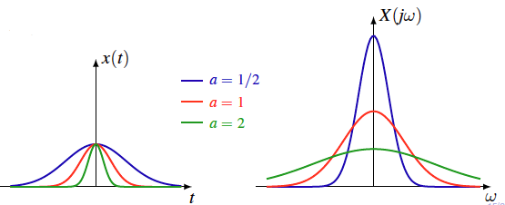

## 微分

$$x^{\prime}(t) \stackrel{\mathcal{F}}{\longleftrightarrow} j \omega X(j \omega), \quad x^{(k)}(t) \stackrel{\mathcal{F}}{\longleftrightarrow}(j \omega)^{k} X(j \omega)$$

### 证明：积分符号下求导 (Differentiate under integral sign)

利用逆傅里叶变换（合成方程）：
$$x(t) = \frac{1}{2\pi} \int_{\mathbb{R}} X(j\omega)e^{j\omega t} d\omega \Longrightarrow x'(t) = \frac{1}{2\pi} \int_{\mathbb{R}} j\omega X(j\omega)e^{j\omega t} d\omega$$

由此可见，时域中的求导操作对应于频域中乘以 $j\omega$。

### 微分器及其频率响应

$y = x'$ 是一个**微分器**的输出，该系统的频率响应为：

$$H(j\omega) = \mathcal{F} \{\delta'\} (j\omega) = \int_{\mathbb{R}} \delta'(t)e^{-j\omega t} dt = -\left. \frac{d}{dt} e^{-j\omega t} \right|_0 = j\omega$$

### 滤波器特性分析

根据关系式 $Y(j\omega) = H(j\omega)X(j\omega)$，微分器具有以下滤波特性：

- **放大高频分量**：由于 $|H(j\omega)| = |\omega|$，随着频率 $\omega$ 增加，增益线性增加。
- **抑制低频分量**：频率越低，增益越小。
- **完全消除直流 (DC) 分量**：在 $\omega = 0$ 处，$H(j0) = 0$，因此信号中的常数部分会被完全滤除。

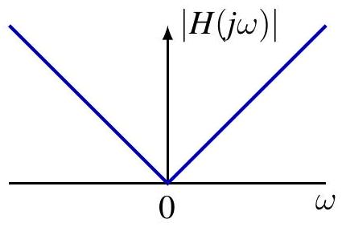

### 总结

微分器本质上是一个**高通滤波器**。它对信号中的突变（高频）非常敏感，常用于边缘检测；但同时也会放大信号中的高频噪声。

## 积分

$$y(t)=\int_{-\infty}^{t} x(\tau) d \tau \stackrel{\mathcal{F}}{\longleftrightarrow} Y(j \omega)=\frac{1}{j \omega} X(j \omega)+\pi X(0) \delta(\omega)$$

由于 $x(t) = y'(t)$，根据微分性质可知：
$$X(j\omega) = j\omega Y(j\omega) \Longrightarrow Y(j\omega) = \frac{1}{j\omega} X(j\omega) \quad (\text{对于 } \omega \neq 0)$$

### 直流 (DC) 分量的直观分析

直观地看，$y(t)$ 具有直流分量。其平均值 $\bar{y}$ 计算如下：

$$\begin{aligned}
\bar{y} &= \lim_{T \to \infty} \frac{1}{2T} \int_{-T}^{T} y(t) dt = \lim_{T \to \infty} \frac{1}{2T} \int_{-T}^{T} \int_{\mathbb{R}} x(\tau)u(t - \tau) d\tau dt \\
&= \int_{\mathbb{R}} x(\tau) \left( \lim_{T \to \infty} \frac{1}{2T} \int_{-T}^{T} u(t - \tau) dt \right) d\tau = \frac{1}{2} X(0)
\end{aligned}$$

因此，$Y$ 还包含一个由直流分量产生的冲激项：
$$2\pi \bar{y} \delta(\omega) = \pi X(0) \delta(\omega)$$

### 结论：积分性质的完整形式

综合以上两部分，若 $y(t) = \int_{-\infty}^{t} x(\tau) d\tau$，则其傅里叶变换为：
$$Y(j\omega) = \frac{1}{j\omega} X(j\omega) + \pi X(0) \delta(\omega)$$